# ARIMA Models

# ARIMA Models

## Introduction

ARIMA, which stands for **A**uto**r**egressive **I**ntegrated **M**oving-**A**verage, is a time series model specification which combines typical Autoregressive ([AR](https://en.wikipedia.org/wiki/Autoregressive_model)) and Moving Average ([MA](https://en.wikipedia.org/wiki/Moving-average_model)), while also allowing for unit roots. An ARIMA thus has three parameters:
$$p$$
, which denotes the AR parameters,
$$q$$
, which denotes the MA parameters, and
$$d$$
, which represents the number of times an ARIMA model must be differenced in order to get an ARMA model. A univariate
$$ARIMA(p, 1, q)$$
model can be specified by

$$y_{t}=\alpha + \delta t
+u_{t}$$

where
$$u_{t}$$
is an
$$ARMA(p+1,q)$$
. Particularly,

$$\rho(L)u_{t}=\theta(L)\varepsilon_{t}$$

where
$$\varepsilon_{t}\sim
WN(0,\sigma^{2})$$
and

$$\begin{align}
\rho(L)&=(1-\rho_{1}L-\dots-\rho_{p+1}L^{p+1})\\
\theta(L)&=1+\theta_{1}L+\dots+\theta_{q}L^{q}
\end{align}$$

Recall that
$$L$$
is the lag operator and
$$\theta(L)$$
must be invertible. If we factor
$$\rho(L)=(1-\lambda_{1}L)\cdots(1-\lambda_{p+1}L)$$
, where
$$\{\lambda\}$$
are the eigenvalues of the
$$F$$
matrix (see [LOST: State-Space Models]({{ “/Time_Series/State_Space_Models.html” | relative_url }})), then define
$$\phi(L)=(1-\lambda_{1}L)\cdots(1-\lambda_{p}L)$$
. It follows that

$$\begin{align*}
\phi(L)(1-L)u_{t}&=\theta(L)\varepsilon_{t}
\implies \phi(L)\Delta u_{t}&=\theta(L)\varepsilon_{t}
\end{align*}$$

$$\phi(L)(1-L)^{d}y_{t}=\theta(L)\varepsilon_{t}$$

which leads to
$$\Delta^{d} y_{t}$$
being an
$$ARMA(p,q)$$
process.

## Keep in Mind

- Error terms are generally assumed to be from a white noise process with 0 mean and constant variance
- A non-zero intercept or mean in
  $$\Delta
  y_{t}$$
  is reffered to as *drift*, and can be speciied in functions below
- If your model has no unit roots, it may be best to consider an ARMA, AR, or MA model
- You can always test the presence of a unit root afer fitting your model using a [unit root test](https://en.wikipedia.org/wiki/Unit_root_test), such as the [Augmented Dickey-Fuller test](https://en.wikipedia.org/wiki/Augmented_Dickey%E2%80%93Fuller_test)

## Also Consider

- AR Models ([LOST: AR models]({{ “/Time_Series/AR-models.html” | relative_url }}))
- MA Models ([LOST: MA models]({{ “/Time_Series/MA_Model.html” | relative_url }}))
- ARMA Models (LOST: ARMA models)
- Seasonal ARIMA models, if you suspect the time series data you are trying to fit with is subject to seasonality
- If you are working with State-Space models, you may be interested in trend-cycle decomposition with ARIMA. This involves breaking down the ARIMA into a “trend” component, which encapsulates permanent effects (stochastic and deterministic), and a “cyclical” effect, which encapsulates transitory, non-permanent variation in the model. One extension of this is the Unobserved Components ARIMA, or UC-ARIMA

# Implementations

## Julia

ARIMA(p,d,q) models in Julia can be estimated using the StateSpaceModels.jl package, which also allows for the estimation of a variety of time series models that have linear state-space representations.

Begin by importing and loading necessary packages into your work environment.

```julia
# Load necessary packages
using StateSpaceModels, CSV, Dates, DataFrames, LinearAlgebra
```

You can then download the `GDPC1.csv` dataset using the CSV.jl package, and store it as a `DataFrame` object.

```julia
# Import (download) data
data = CSV.read(download("https://github.com/LOST-STATS/lost-stats.github.io/raw/source/Time_Series/Data/GDPC1.csv"), DataFrame)
```

The data can then be assigned a general ARIMA(p,d,q) representation.

```julia
# Specify GDPC1 series as an ARIMA(2,2,2) model
model = SARIMA(data.GDPC1, order = (2,2,2))
```

Lastly, the above-specified model can be estimated using the `fit!` function, and the estimation results printed using the `results` function. The sole input for both of these functions is the `model` object that contains the chosen data series and its assigned ARIMA structure.

```julia
# Fit (estimate) the model
fit!(model)

# Print estimates
results(model)
```

## R

The `stats` package, which comes standard-loaded on an RStudio workspace, includes the function `arima`, which allows one to estimate an arima model, if they know
$$p,d,$$
and
$$q$$
already.

```
#load data
gdp = read.csv("https://github.com/LOST-STATS/lost-stats.github.io/raw/source/Time_Series/Data/GDPC1.csv")
gdp_ts = ts(gdp[ ,2], frequency = 4, start = c(1947, 01), end = c(2019, 04))
y = log(gdp_ts)*100
```

The output for `arima()` is a list. Use `$coef` to get only the AR and MA estimates. Use `$model` to get the entire estimated model. If you want to see the maximized log-likelihood value,
$$sigma^{2}$$
, and AIC, simply run the function on the data:

```
#estimate an ARIMA(2,1,2) model
lgdp_arima = arima(y, c(2,1,2))

#To see maximized log-likelihood value, $sigma^{2}$, and AIC:
lgdp_arima

#To get only the AR and MA parameter estimates:
lgdp_arima$coef

#To see the estimated model:
lgdp_arima$model
```

In the example above, we are using an *d = 1* ARIMA model, or a ARIMA model with one unit root. As noted above, if we want to manually test a time series for one or more unit roots, we run an Augmented Dicky-Fuller test through the `tseries::adf.test()` function. Note that the null hypothesis for a Augmented Dicky-Fuller tests is that there is a unit root.

[output not shown]

In this case, we fail to reject the null hypothesis, meaning that there is at least one unit root in the data. To test for a second unit root, we can run an Augmented Dicky-Fuller test on the first difference of the time series.

[output not shown]

We can reject the null hypothesis that there is a unit root in the first difference of the data at the 1% level. This implies that there is only one unit root in the series, and a *d = 1* model is best suited for this data.
The `forecast` package includes the ability to *auto-select* ARIMA models. This is of particular use when one would like to automate the selection of
$$p,q$$
, and
$$d$$
, without writing their own function. According to [David Childers](https://donskerclass.github.io/Forecasting/ARIMA.html#:~:text=Condition%20for%20stationarity%20or%20an%20ARMA%20model%20is,roots%2C%20differencing%20%5C%28y_t%5C%29%20d%20times%20can%20restore%20stationarity), `forecast::auto.arima()` takes the following steps: - Use the [KPSS](https://en.wikipedia.org/wiki/KPSS_test) to test for unit roots, differencing the series unit stationary - Create likelihood functions at various orders of
$$p,q$$
- Use AIC to choose
$$p,q$$
, then estimate via Maxmium Likelihood to select
$$p,q$$

```
library(forecast)

#Finding optimal parameters for an ARIMA using the previous data
lgdp_auto = auto.arima(y)

#A seasonal model was selected, with non-seasonal components (p,d,q)=(1,2,1), and seasonal components (P,D,Q)=(2,0,1)
```

After specifying an ARIMA model, it is often prudent to check the model’s residuals for time dependency. Ideally, there should be no autocorrelation in the residuals. The `forecast::checkresiduals()` function runs a Ljung-Box test which checks for autocorrelation in a time series (in this case the residuals from our ARIMA model). It also generates a visualization of the residuals

[output not shown]

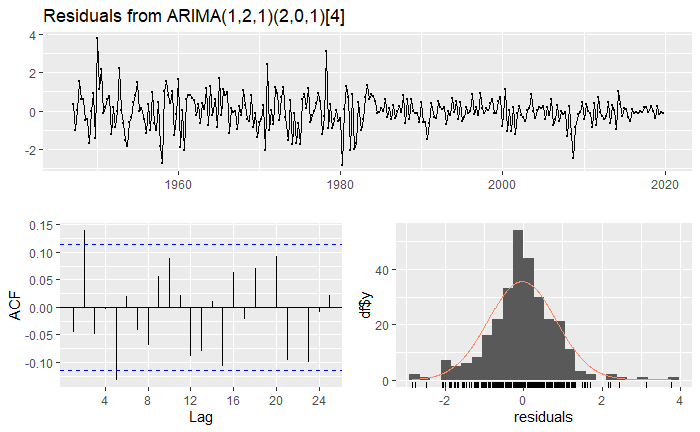

The Ljung-Box test and the plot show that there is autocorrelation in the residuals. We can reject the null-hypothesis that there is no autocorrelation at the 1% level. This illustrates that, while `auto.arima()` is efficient, it is always a good idea to review the model it selects.
`auto.arima()` contains a lot of flexibility. If one knows the value of
$$d$$
, it can be passed to the function. Maximum and starting values for
$$p,q,$$
and
$$d$$
can be specified in the seasonal- and non-seasonal cases. If one would like to restrict themselves to a non-seasonal model, or use a different test, these can also be done. Some of these features are demonstrated below. The method for testing unit roots can also be specified. See `?auto.arima` or [the package documentation](https://cran.r-project.org/web/packages/forecast/forecast.pdf) for more.

```
# Auto-estimate y, specifying:
## non-seasonal
## Using Augmented Dickey-Fuller rather than KPSS
## d=1
## p starts at 1 and does not exceed 4
# no drift
lgdp_ns <- auto.arima(y,
                      seasonal = F,
                      test = "adf",
                      start.p = 1,
                      max.p = 4,
                      allowdrift = F)
#An ARIMA(3,1,0) was specified
lgdp_ns
```

The forecast package also contains the ability to simulate ARIMA data given an ARIMA model. Note that the input here should come from either `forecast::auto.arima()` or `forecast::Arima()`, rather than `stats::arima()`.

```
#Simulate data using a non-seasonal ARIMA()
arima_222 <- Arima(y, c(2,2,2))
sim_arima <- forecast:::simulate.Arima(arima_222)
tail(sim_arima, 20)
```